# Project Week 7

Ananda Putra Wijaya/G1401221111

2024-09-29

# Library

```r
library(ggplot2)
library(tsibble)
library(tseries)
library(MASS)
library(forecast)
library(TSA)
library(TTR)
library(aTSA)
library(graphics)
library(readxl)
library(tseries)
```

# Inisiasi Data

```r
data=read.csv("C:/Tugas/Semester 5/Metode Peramalan Deret Waktu/Minggu 7/Data Project Week 7.csv")
dts=ts(data$Jumlah)
dts
```

```
## Time Series:
## Start = 1
## End = 100
## Frequency = 1
##   [1] 26143 23206 22881 25195 32969 43737 26978 26481 23576 21380 24178 24707
##  [13] 24342 27480 16959 17602 22629 23796 23278 26563 29581 30305 25772 25006
##  [25] 26430 27759 29510 43121 63483 37762 21135 27153 31129 31386  4867 40311
##  [37] 33329 30072 31216  4558 34288 38859 43320 36202 32508 27965 21681 34025
##  [49] 38681  5900 33262 29314 29518 29897  5755 33585 35318 26535 24708  3529
##  [61] 27050 26904 30677 29970  3279 22947 23842 24667 25955 28964 30509 21687
##  [73] 23289 23558 24060 25704 28110 15982 23174 20570 23389 25781 25265 28964
##  [85] 10770 23207 23411 21038 20990 13298 30842 24253 21532 11211 18064 11208
##  [97] 25709 29339 26043 23868
```

```r
latts=ts(dts[1:66])
ujits=ts(dts[67:100])
```

# Model ARIMA(2,1,0)

Berdasarkan hasil analisis yang dilakukan pada pertemuan 6, model yang akan digunakan adalah model **ARIMA(2,1,0)**.

```r
modelfix=Arima(latts, order=c(2,1,0),method="ML")
```

# Analisis Sisaan

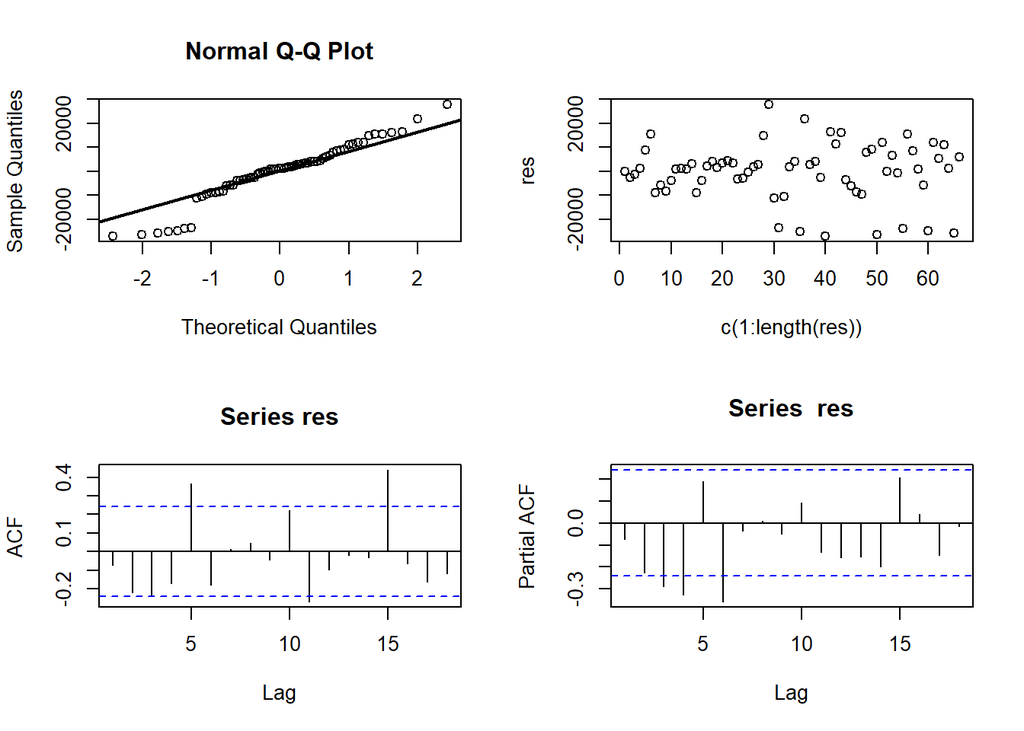

```r
res <- modelfix$residuals
par(mfrow=c(2,2))
qqnorm(res)
qqline(res, col = "black", lwd = 2)
plot(c(1:length(res)),res)
acf(res)
pacf(res)
```

# Uji Formal

## Sisaan Menyebar Normal

```r
ks.test(res,"pnorm")
```

```
##
##  Exact one-sample Kolmogorov-Smirnov test
##
## data:  res
## D = 0.57576, p-value = 2.22e-16
## alternative hypothesis: two-sided
```

$H_0$ : Sisaan menyebar normal

$H_1$ : Sisaan tidak menyebar normal

Menurut uji KS di atas, didapat nilai p mendekati 0, yang kurang dari taraf nyata 5% sehingga tolak H0. Artinya sisaan tidak menyebar normal.

## Autokorelasi

```r
Box.test(res, type = "Ljung")
```

```
##
##  Box-Ljung test
##
## data:  res
## X-squared = 0.37491, df = 1, p-value = 0.5403
```

$H_0$ : Sisaan saling bebas

$H_1$ : Sisaan tidak tidak saling bebas

Menurut uji Ljung-Box di atas, didapat nilai p sebesar 0.5403, yang lebih besar dari taraf nyata 5% sehingga tak tolak H0. Artinya sisaan saling bebas.

## Homoskedastisitas

```r
Box.test((res)^2, type = "Ljung")
```

```
##
##  Box-Ljung test
##
## data:  (res)^2
## X-squared = 0.77596, df = 1, p-value = 0.3784
```

$H_0$ : Ragam sisaan homogen

$H_1$ : Ragam sisaan tidak homogen

Menurut uji Ljung-Box terhadap sisaan kuadrat di atas, didapat nilai p sebesar 0.3784, yang lebih besar dari taraf nyata 5% sehingga tak tolak H0. Artinya ragam sisaan homongen.

## Nilai tengah sisaan sama dengan 0

```r
t.test(res, mu = 0, conf.level = 0.95)
```

```
##
##  One Sample t-test
##
## data:  res
## t = -0.13568, df = 65, p-value = 0.8925
## alternative hypothesis: true mean is not equal to 0
## 95 percent confidence interval:
##  -3065.153  2675.174
## sample estimates:
## mean of x
## -194.9894
```

$H_0$ : nilai tengah sisaan sama dengan 0

$H_1$ : nilai tengah sisaan tidak sama dengan 0

Menurut uji-t di atas, didapat nilai p sebesar 0.8925, yang lebih besar dari taraf nyata 5% sehingga tak tolak H0. Artinya nilai tengah sisaan sama dengan nol.

# Forecasting

Selanjutnya akan dilakukan proses *forecasting*. Akan dilakukan peramalan untuk 34 hari ke depan.

```r
jadidukun <- forecast::forecast(modelfix, h = 34)
jadidukun
```

```
##     Point Forecast       Lo 80    Hi 80      Lo 95    Hi 95
##  67       21177.20   5976.8204 36377.59  -2069.776 44424.18
##  68       15981.94   -939.6053 32903.48  -9897.330 41861.21
##  69       19184.69    989.3413 37380.04  -8642.696 47012.08
##  70       19159.75  -1356.1612 39675.66 -12216.627 50536.12
##  71       18179.27  -3946.2219 40304.76 -15658.750 52017.29
##  72       18687.87  -4849.4103 42225.14 -17309.292 54685.02
##  73       18732.12  -6303.0349 43767.27 -19555.845 57020.08
##  74       18551.79  -7840.1584 44943.74 -21811.212 58914.79
##  75       18630.18  -9032.5645 46292.93 -23676.339 60936.71
##  76       18646.06 -10256.9944 47549.11 -25557.347 62849.47
##  77       18613.64 -11471.7619 48699.04 -27398.011 64625.29
##  78       18625.28 -12593.8168 49844.37 -29120.207 66370.76
##  79       18629.39 -13687.5637 50946.34 -30795.124 68053.90
##  80       18623.68 -14754.2367 52001.59 -32423.438 69670.79
```

[output cut: 20 more lines]

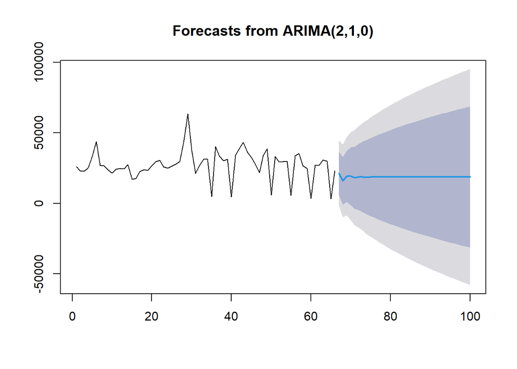

```r
E_jadidukun <- jadidukun$mean
plot(jadidukun)
```

Berdasarkan plot ramal di atas, dapat dilihat bahwa hasil ramalan model **ARIMA(2,1,0)** nampak stabil hingga akhir periode. Selanjutnya akan dicari nilai akurasi hasil ramal model **ARIMA(2,1,0)**.

## Keakuratan Forecasting

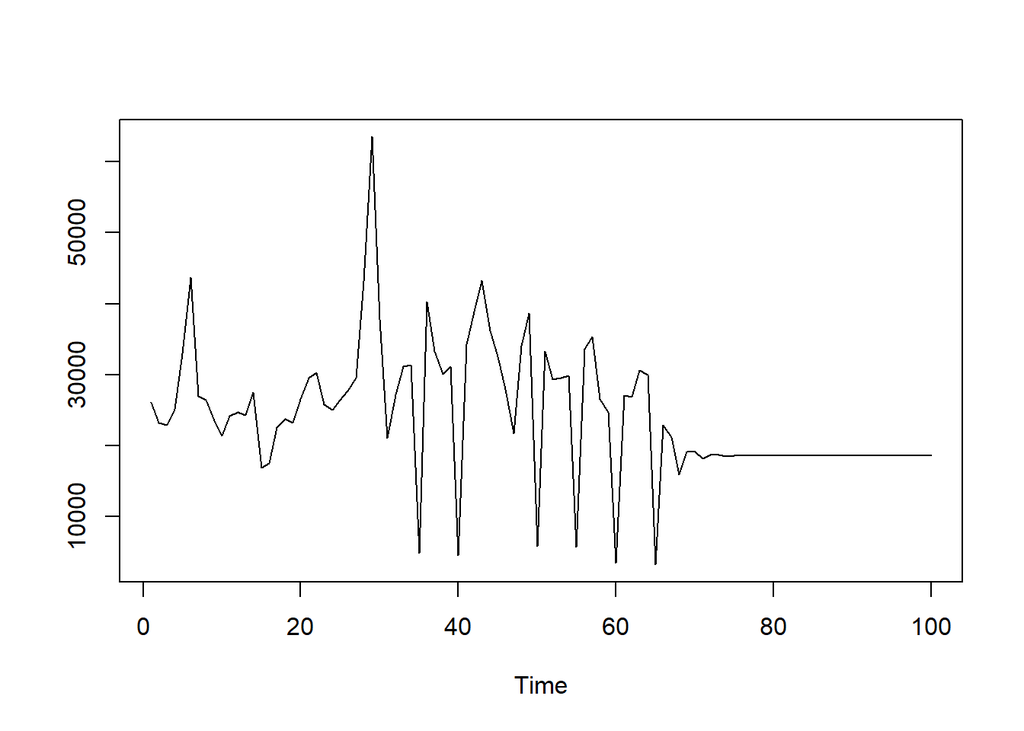

```r
lat66 <- ts(latts[66])
hasildukun=c(lat66,jadidukun$mean)
hasil = ts(hasildukun, start = 66)
ts.plot(latts, hasil)
```

```r
comparison<-matrix(data=c(head(ujits, n=34), hasil),
                     nrow = 34, ncol = 2)
colnames(comparison)<-c("Aktual","Hasil Forecast")
comparison
```

```
##       Aktual Hasil Forecast
##  [1,]  23842       22947.00
##  [2,]  24667       21177.20
##  [3,]  25955       15981.94
##  [4,]  28964       19184.69
##  [5,]  30509       19159.75
##  [6,]  21687       18179.27
##  [7,]  23289       18687.87
##  [8,]  23558       18732.12
##  [9,]  24060       18551.79
## [10,]  25704       18630.18
## [11,]  28110       18646.06
## [12,]  15982       18613.64
## [13,]  23174       18625.28
## [14,]  20570       18629.39
```

[output cut: 20 more lines]

```r
accuracy(ts(hasil[-1]), head(ujits, n=34))
```

```
##                ME    RMSE      MAE      MPE    MAPE      ACF1 Theil's U
## Test set 4244.674 6751.07 6081.154 12.15083 27.7372 0.0717773 0.7355075
```

Karena nilai *MAPE* yang didapat sangat besar, maka dapat dikatakan bahwa hasil ramalan tidak bagus.